# Random Forest Classification Analysis

Prelim Analysis

Author

Matt McGehee (Advisor: Dr. Seals)

Published

November 13, 2024

# Random Forest Classification Analysis

The objective of this analysis is to apply a Random Forest classification model to predict whether an `OPCO` falls within the top 25% of revenue generators (`high_revenue`) using various predictor variables. This approach helps identify key distribution channels that drive the most revenue, aiding strategic business decisions and targeted marketing efforts.

The analysis is performed using the `randomForest` package in R (R Core Team 2024), and all necessary steps for data cleaning and model training are outlined in the code sections below.

### Data Cleaning and Preprocessing

The dataset was initially examined for irrelevant product entries such as shipping line items and customer refunds. These were filtered out to focus exclusively on relevant sales data:

- **Excluded Items**: Shipping charges and other non-product entries, including “OUTBOUND SHIPPING” and “Shipping Charge.”
- **Filters Applied**: Rows with non-positive values for `UnitPrice`, `TotalPrice`, and `qtyOrdered` were removed to ensure only genuine sales transactions were analyzed.

The data was then prepared for modeling, with key columns converted to appropriate types (e.g., categorical encoding of `Product`).

### Feature Selection

The key variables used for predicting high-revenue OPCOs include:

- **`Product`**: The type of product sold.
- **`Substrate`**: The material type of the product.
- **`qtyOrdered`**: The number of units ordered.

These variables were chosen based on their potential impact on revenue generation and their importance in the supply chain.

## Analysis

### Loading Necessary Libraries

```r
# Load necessary libraries
library(ggplot2)
library(dplyr)
library(randomForest)
library(caret)
library(kableExtra)
```

### Data Cleaning and Preprocessing

```r
# Load the data
sales_data <- read.csv("data_as_csv.csv")

# Filter the data to remove shipping line items and any customer credits
exclude_products <- c("OUTBOUND SHIPPING", "Outbound Shipping", "Shipping Charge", "SHIPPING CHARGE")
filtered_data <- sales_data %>%
  filter(UnitPrice > 0, TotalPrice > 0, qtyOrdered > 0, !Product %in% exclude_products) %>%
  filter(!is.na(SalesOrderStatus), !is.na(qtyOrdered), !is.na(UnitPrice), !is.na(Substrate), !is.na(Product))

# Convert SalesOrderStatus to a factor variable
filtered_data$SalesOrderStatus <- as.factor(filtered_data$SalesOrderStatus)

# Apply Top-N Encoding to the 'Product' column
top_n <- 50  # Keep the top 50 most common categories
top_products <- names(sort(table(filtered_data$Product), decreasing = TRUE))[1:top_n]
filtered_data$Product <- factor(
  ifelse(filtered_data$Product %in% top_products,
         as.character(filtered_data$Product),
         "Other")
)

# Aggregate TotalPrice by OPCO to get total revenue per OPCO
opco_revenue <- filtered_data %>%
  group_by(OPCO) %>%
  summarise(total_revenue = sum(TotalPrice, na.rm = TRUE))

# Create a binary/label column indicating if an OPCO is in the top 25% of revenue
revenue_threshold <- quantile(opco_revenue$total_revenue, 0.75)  # 75th percentile
opco_revenue <- opco_revenue %>%
  mutate(high_revenue = ifelse(total_revenue >= revenue_threshold, 1, 0))

# Merge this information back with the original data for feature use
filtered_data <- left_join(filtered_data, opco_revenue, by = "OPCO")

# Prepare features and target variable
features <- filtered_data %>%
  select(Product, Substrate, qtyOrdered)

# Convert character columns to factors
features <- features %>%
  mutate(across(where(is.character), as.factor))

# Set target variable (high_revenue)
target <- filtered_data$high_revenue
```

### Model Training and Evaluation

#### Training the Random Forest Model

```r
set.seed(123)

train_index <- sample(1:nrow(features), 0.7 * nrow(features))
train_features <- features[train_index, ]
test_features <- features[-train_index, ]
train_target <- target[train_index]
test_target <- target[-train_index]

rf_model <- randomForest(x = train_features, y = as.factor(train_target), ntree = 100, importance = TRUE)
```

#### Model Evaluation on Test Set

```r
# Predict on test set
test_pred <- predict(rf_model, newdata = test_features)

# Confusion matrix using the binary `high_revenue` variable as the reference
conf_matrix <- confusionMatrix(as.factor(test_pred), as.factor(test_target))

# Extract the confusion matrix table
conf_matrix_table <- as.data.frame(conf_matrix$table)

# Display Confusion Matrix
colnames(conf_matrix_table) <- c("Predicted", "Actual", "Frequency")

ggplot(conf_matrix_table, aes(x = Actual, y = Predicted, fill = Frequency)) +
  geom_tile(color = "white") +
  geom_text(aes(label = Frequency), color = "black", size = 5) +
  scale_fill_gradient(low = "#F1EEF6", high = "#045A8D") +
  theme_minimal() +
  labs(title = "Confusion Matrix for High Revenue Prediction", x = "Actual", y = "Predicted") +
  theme(plot.title = element_text(hjust = 0.5))
```

Table 1: Confusion Matrix

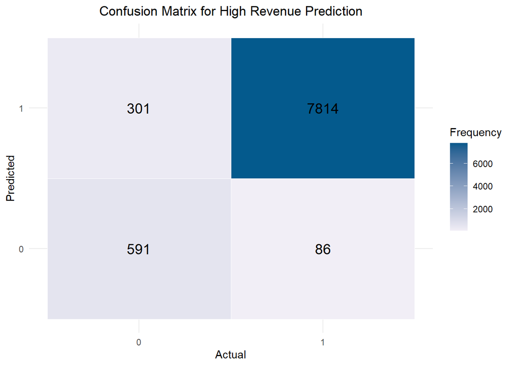

- **True Negatives (TN)**: 591
- **False Positives (FP)**: 301
- **False Negatives (FN)**: 86
- **True Positives (TP)**: 7814

#### Model Statistics

```r
# Extract relevant statistics from the confusion matrix object
stats <- data.frame(
  Metric = c("Accuracy", "95% CI", "Kappa", "Sensitivity", "Specificity", "Pos Pred Value",
             "Neg Pred Value", "Prevalence", "Detection Rate", "Balanced Accuracy"),
  Value = c(
    round(conf_matrix$overall['Accuracy'], 3),
    paste0("(", round(conf_matrix$overall['AccuracyLower'], 3), ", ", round(conf_matrix$overall['AccuracyUpper'], 3), ")"),
    round(conf_matrix$overall['Kappa'], 3),
    round(conf_matrix$byClass['Sensitivity'], 5),
    round(conf_matrix$byClass['Specificity'], 5),
    round(conf_matrix$byClass['Pos Pred Value'], 5),
    round(conf_matrix$byClass['Neg Pred Value'], 5),
    round(conf_matrix$byClass['Prevalence'], 5),
    round(conf_matrix$byClass['Detection Rate'], 5),
    round(conf_matrix$byClass['Balanced Accuracy'], 5)
  )
)

# Display Model Statistics
stats %>%
  kable("html") %>%
  kable_styling(full_width = F, position = "center", bootstrap_options = c("striped", "hover"))
```

Table 2: Model Statistics

|  | Metric | Value |
| --- | --- | --- |
| Accuracy | Accuracy | 0.956 |
|  | 95% CI | (0.951, 0.96) |
| Kappa | Kappa | 0.73 |
| Sensitivity | Sensitivity | 0.66256 |
| Specificity | Specificity | 0.98911 |
| Pos Pred Value | Pos Pred Value | 0.87297 |
| Neg Pred Value | Neg Pred Value | 0.96291 |
| Prevalence | Prevalence | 0.10146 |
| Detection Rate | Detection Rate | 0.06722 |
| Balanced Accuracy | Balanced Accuracy | 0.82583 |

### ROC Curve Analysis

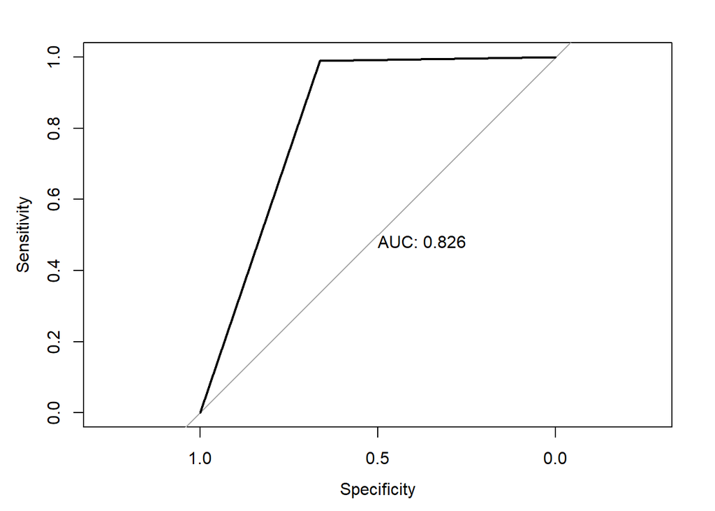

Figure 1: ROC Curve for High Revenue Prediction

```r
# ROC Curve and AUC
library(pROC)
roc_curve <- roc(as.numeric(test_target), as.numeric(test_pred))
plot.roc(roc_curve, print.auc = TRUE)
```

The ROC curve shows that the model has an AUC of 0.826, indicating good discriminative ability. This suggests that the model can reliably differentiate between high-revenue and non-high-revenue OPCOs.

### Feature Importance

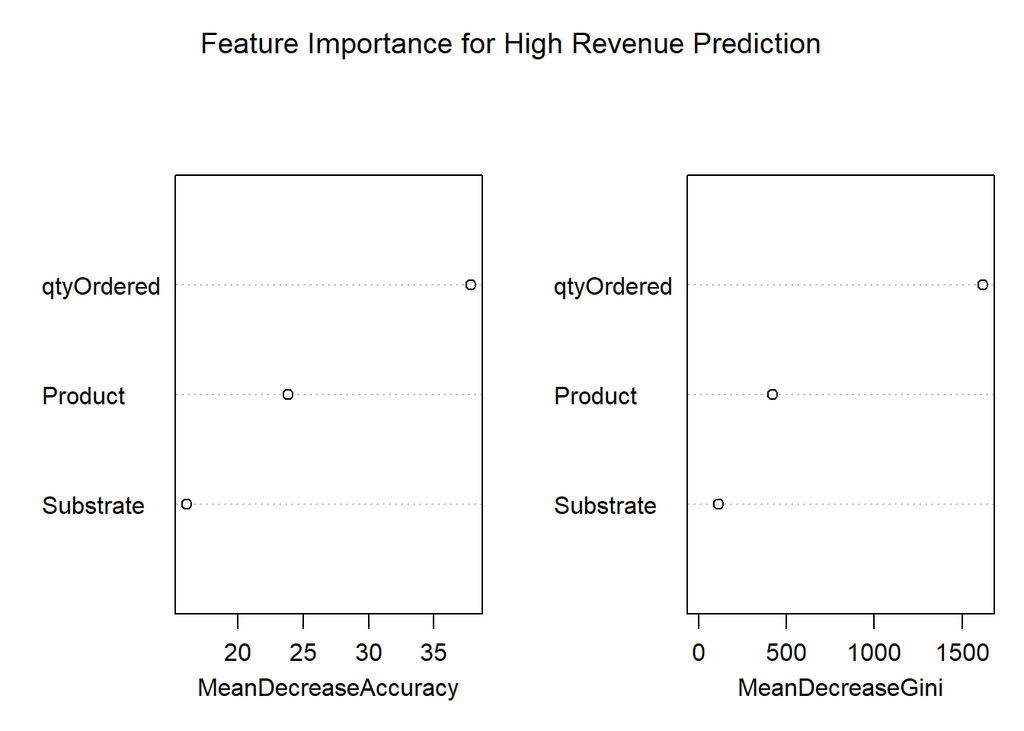

Figure 2: Feature Importance for High Revenue Prediction

```r
# Plot Mean Decrease in Accuracy and Mean Decrease in Gini
varImpPlot(rf_model, main = "Feature Importance for High Revenue Prediction")
```

The most critical features contributing to the model’s predictive power are:

- **`qtyOrdered`**: The strongest predictor of whether an OPCO is a high-revenue generator.
- **`Product`**: Indicates the type of product and its influence on revenue generation.
- **`Substrate`**: Plays a meaningful role but has less impact compared to `qtyOrdered` and `Product`.

## Conclusion

Using this information, decision-makers will be able to predict with fair accuracy where to put their marketing dollars in future campaigns. There is also plenty of room for improvements. Gathering more information and effectively introducing newer predictors could further enhance the model.

## References

R Core Team. 2024. *R: A Language and Environment for Statistical Computing*. Vienna, Austria: R Foundation for Statistical Computing. https://www.R-project.org/.